# Preprocess Data

Chris Callaghan - CORE Lab

12/5/2019

```r
library(raster)
library(sf)
library(tidyverse)
library(igraph)
library(maps)
```

## Generating Polygon Adjacency Matrix

Get governorate polygons:

```r
syria_governorate <- raster::getData("GADM", country = "SYR", level = 1) %>%
  sf::st_as_sf()
```

Add polygon ids from Athena:

```r
syria_governorate <- syria_governorate %>%
  mutate(neighborhood_id = case_when(NAME_1 == "Al Ḥasakah" ~ "Hasakah [NSYBCHA] (Hasakah Governorate)",
                                     NAME_1 == "Aleppo" ~ "Aleppo and Idlib Province [NSYAI] (Halab and Idlib governorates minus Aleppo City and Ayn al Arab Halab governorate districts)",
                                     NAME_1 == "Ar Raqqah" ~ "Raqqa Greater [NSYBCRA] (Raqqa Governorate minus Raqqa district plus Aleppo Governorate district Ayn al Arab)",
                                     NAME_1 == "As Suwayda'" ~ "Suwayda [NSYSU] (Suwayda Governorate)",
                                     NAME_1 == "Damascus" ~ "Damascus City [NSYDDDMCIT] (Damascus Governorate)",
                                     NAME_1 == "Dar`a" ~ "Daraa Governorate (Daraa Governorate minus the population of Daraa City)",
                                     NAME_1 == "Dayr Az Zawr" ~ "Deir Az Zur [NSYBCDZ] (Deir Az Zur Governorate)",
                                     NAME_1 == "Hamah" ~ "Homs and Hama [NSYHH] (Homs and Hama Governorates)",
                                     NAME_1 == "Hims" ~ "Homs and Hama [NSYHH] (Homs and Hama Governorates)",
                                     NAME_1 == "Idlib" ~ "Aleppo and Idlib Province [NSYAI] (Halab and Idlib governorates minus Aleppo City and Ayn al Arab Halab governorate districts)",
                                     NAME_1 == "Lattakia" ~ "Latakia [NSYLT] (Latakia Governorate)",
                                     NAME_1 == "Quneitra" ~ "Daraa Governorate (Daraa Governorate minus the population of Daraa City)",
                                     NAME_1 == "Rif Dimashq" ~ "Damascus Governorate [NSYDD] (Rif Dimashq Governorate (minus the population of Damascus Governorate))",
                                     NAME_1 == "Tartus" ~ "Latakia [NSYLT] (Latakia Governorate)")) %>%
  dplyr::select(neighborhood_id)
```

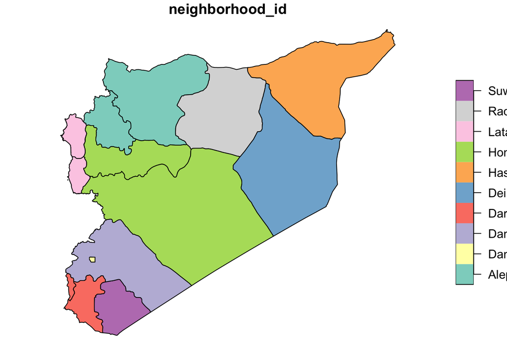

Get city coordinates for Aleppo, Raqqah, and Dar’a City, then add a buffer to transform them into polygons:

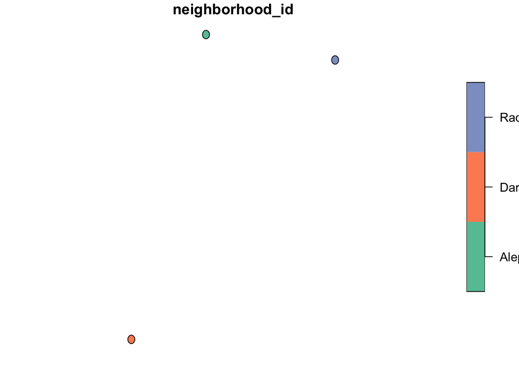

```r
syria_cities <- maps::world.cities %>%
  filter(name == "Dar'a" | name == "Aleppo" | name == "ar-Raqqah") %>%
  mutate(neighborhood_id = case_when(name == "Aleppo"    ~ "Aleppo City [NSYAICIT] (Mount Simeon / Jabal Sem’an District of Aleppo Governorate)",
                                     name == "Dar'a"     ~ "Daraa City [NSYDDDACIT] (Daraa District)",
                                     name == "ar-Raqqah" ~ "Raqqa City [NSYBCRACIT] (Raqqa district of Raqqa Governorate and city)")) %>%
  sf::st_as_sf(coords = c("long", "lat"),
               crs = st_crs(syria_governorate)) %>%
  sf::st_buffer(dist = .05) %>%
  dplyr::select(neighborhood_id)
```

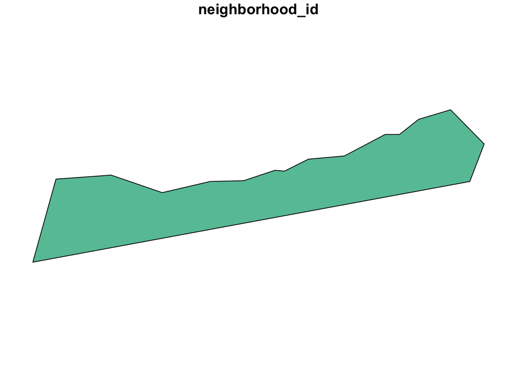

```r
# Info here: https://www.r-spatial.org/r/2017/01/30/mapedit_intro.html
library(mapview)
library(mapedit)
safe_zone <- mapview() %>%
  editMap()
mapview(safe_zone$finished)
safe_zone <- safe_zone$drawn %>%
  mutate(neighborhood_id = "Raqqa Greater Turkish Safe Zone [NSYBCRASZ] (Turkish occupied northern Raqqa and Hasakah Governorates)") %>%
  dplyr::select(neighborhood_id)
```

Join the cities, governorates, and safe zone. Then unionize neighborhood ids:

```r
syria_merged <- rbind(syria_governorate, syria_cities, safe_zone) %>%
  group_by(neighborhood_id) %>%
  summarise(geometry = sf::st_combine(geometry)) %>%
  ungroup()
# saveRDS(syria_merged, file = here::here("data/syria_merged.rds"))
```

Using this merged data frame, generate an adjacency matrix for polygons:

```r
intersection_matrix <- as.matrix(st_intersects(syria_merged, sparse = FALSE))
row.names(intersection_matrix) <- syria_merged$neighborhood_id
colnames(intersection_matrix) <- syria_merged$neighborhood_id
intersection_matrix <- ifelse(intersection_matrix == TRUE, 1, 0)
```

The `intersection_matrix` can be graphed as a uni-mode matrix where nodes represent polygons, like so:

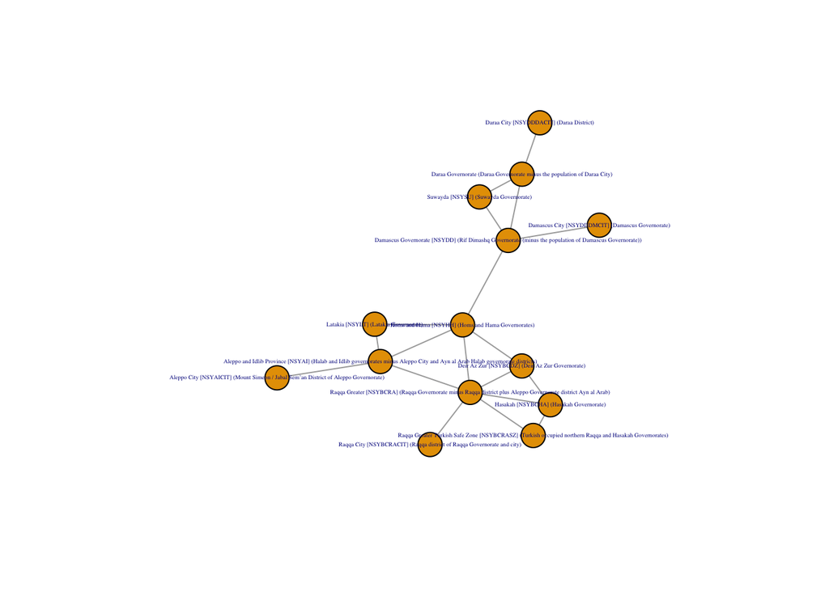

```r
g_adj_poly <- igraph::graph_from_adjacency_matrix(intersection_matrix,
                                                  mode = "undirected",
                                                  diag = FALSE)
plot.igraph(g_adj_poly,
            vertex.label.cex = 0.3)
```

## Process Demographic Data

First load and inspect the data:

```r
df <- readr::read_csv(here::here("data/migration_decision_making_syria.csv")) %>%
  glimpse()
```

```
## Observations: 69
## Variables: 10
## $ `Neighborhood of Syria`                                      <chr> "Al…
## $ `Civilian Group`                                             <chr> "Sy…
## $ Population                                                   <dbl> 920…
## $ `Mood at Week 1 (October 1, 2019)`                           <chr> "Di…
## $ `Security at Week 1 (October 1, 2019)`                       <chr> "No…
## $ `Vertical Relationship to Syrian Government Actor (Week 1)`  <dbl> 0.0…
## $ `Vertical Relationship to Turkish Government Actor (Week 1)` <dbl> -0.…
## $ `Vertical Relationship to US Government Actor (Week 1)`      <dbl> 0.2…
## $ `Vertical Relationship to Kurdish Actor (Week 1)`            <dbl> 0.6…
## $ `Vertical Relationship to ISIL Actor (Week 1)`               <dbl> -0.…
```

Some of the strings can be cleaned up a bit, namely the `Civilian Group` string as it includes the group of interest and a location. Thus, making each group attached to a location a unique value. In order to determined shared ethnic group membership between polygons, the location portion of the `Civilian Group` string must be dropped.

```r
df_clean <- df %>%
  mutate(
    group           = str_extract(`Civilian Group`,
                                       "^(.*?)(?=\\sof)")#,
    # neighborhood_id = str_extract(`Neighborhood of Syria`,
    #                                    "(?<=\\[)(.*?)(?=\\])"),
    # group_id        = str_extract(`Civilian Group`,
    #                                    "(?<=\\()(\\w+)(?=\\)$)"),
         ) %>%
  dplyr::select(neighborhood_id = `Neighborhood of Syria`, group)
```

From the edge list generated above, we can create a bipartate graph that can be in turn projected to create one-mode graph between polygons sharing one or more ethnic groups:

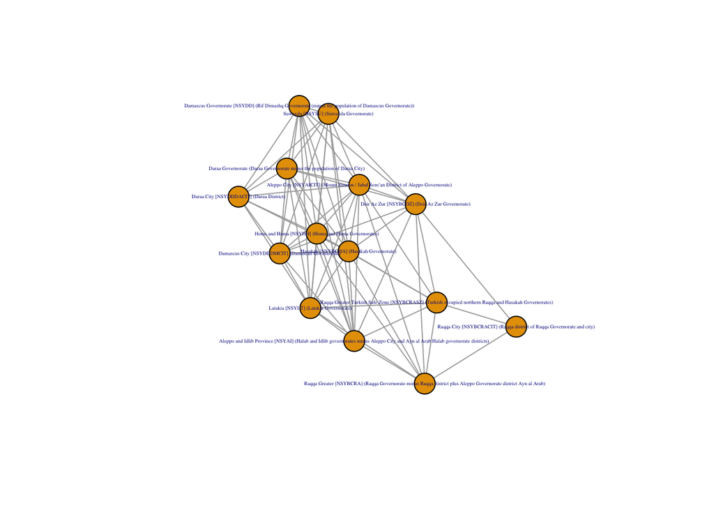

```r
g_bip <- igraph::graph_from_data_frame(df_clean[1:54, 1:2])
V(g_bip)$type <- bipartite_mapping(g_bip)$type
prov_prov <- bipartite_projection(g_bip)$proj1
```

```r
prov_mat <- as.matrix(get.adjacency(prov_prov))
```

## Aggregating Demographic Data and Polygon Adjacency

First, sum up both matrices:

```r
sum_matrix <- matrix(
  mapply(sum,
         prov_mat,
         intersection_matrix,
         MoreArgs=list(na.rm=T)),
  ncol = NROW(intersection_matrix)
  )
```

Clean up the matrix to include only edges with a value of 2 or more:

```r
sum_matrix <- ifelse(sum_matrix > 1, 1, 0)
rownames(sum_matrix) <- rownames(intersection_matrix)
colnames(sum_matrix) <- colnames(intersection_matrix)
# saveRDS(sum_matrix, file = here::here("data/sum_matrix.rds"))
```

Generate a graph from this matrix

```r
g_sum_matrix <- igraph::graph_from_adjacency_matrix(sum_matrix)
visNetwork::visIgraph(g_sum_matrix)
```

[interactive chart not shown]

Generate a map with these nodes and the coordinates from the `sf` object used in the first section:

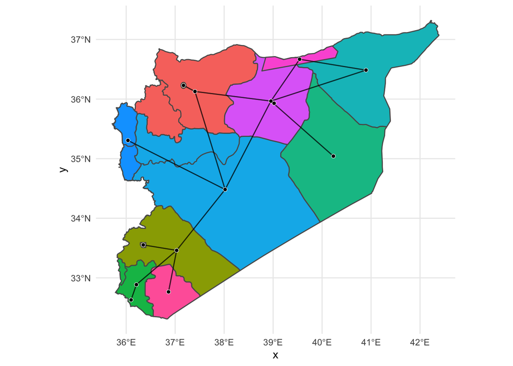

```r
coords <- do.call(rbind, st_geometry(st_centroid(syria_merged))) %>%
  as_tibble() %>%
  setNames(c("lon","lat")) %>%
  mutate(id = syria_merged$neighborhood_id)
edges <- get.data.frame(g_sum_matrix, "edges")

edges_geom <- edges %>%
  inner_join(coords %>% select(id, lon, lat), by = c('from' = 'id')) %>%
  rename(x = lon, y = lat) %>%
  inner_join(coords %>% select(id, lon, lat), by = c('to' = 'id')) %>%
  rename(xend = lon, yend = lat)

syria <- raster::getData(name = "GADM", country = "Syria", level = 1) %>%
  st_as_sf()

mycolors = c(RColorBrewer::brewer.pal(name="Dark2", n = 8), RColorBrewer::brewer.pal(name="Paired", n = 6))

ggplot() +
  theme_minimal() +
  geom_sf(data = syria_merged, show.legend = FALSE, aes(fill = neighborhood_id)) +
  geom_curve(data = edges_geom, aes(x = x, y = y, xend = xend, yend = yend),
             curvature = 0, alpha = 0.5) +
  geom_point(aes(x = lon, y = lat),
             size = 1.4,
             colour = "white",
             data = coords) +
  geom_point(aes(x = lon, y = lat#,
                 #colour = factor(id)
                 ),
             size = 1,
             colour = "black",
             data = coords,
             show.legend = FALSE) +
  scale_color_manual(values = mycolors)
```